# Equitable Distribution Report

Sabrina xie

2023-01-24

## Read in data

Data for median income, spending & collections from Eversource, UI in 2019, 2020 and 2021 filed under C&LM.

Data for demographics:

There are some problems with census tract numbers in the utility data so some demographic data does not collate properly.

## Tables

### Distressed tracts

Overall trend toward closing gaps

- Distressed tracts: median income <60% state median income
- Small load: <100 kWh

```
## # A tibble: 6 × 5
##   collections disbursements Utility  Year equitable
##         <dbl>         <dbl> <chr>   <dbl> <chr>
## 1      24.9         19.9    UI       2019 NO
## 2       0.341        0.0638 ES       2019 NO
## 3      24.1         15.3    UI       2020 NO
## 4       0.292        0.326  ES       2020 YES
## 5      24.5         22.9    UI       2021 NO
## 6       5.78        12.6    ES       2021 YES
```

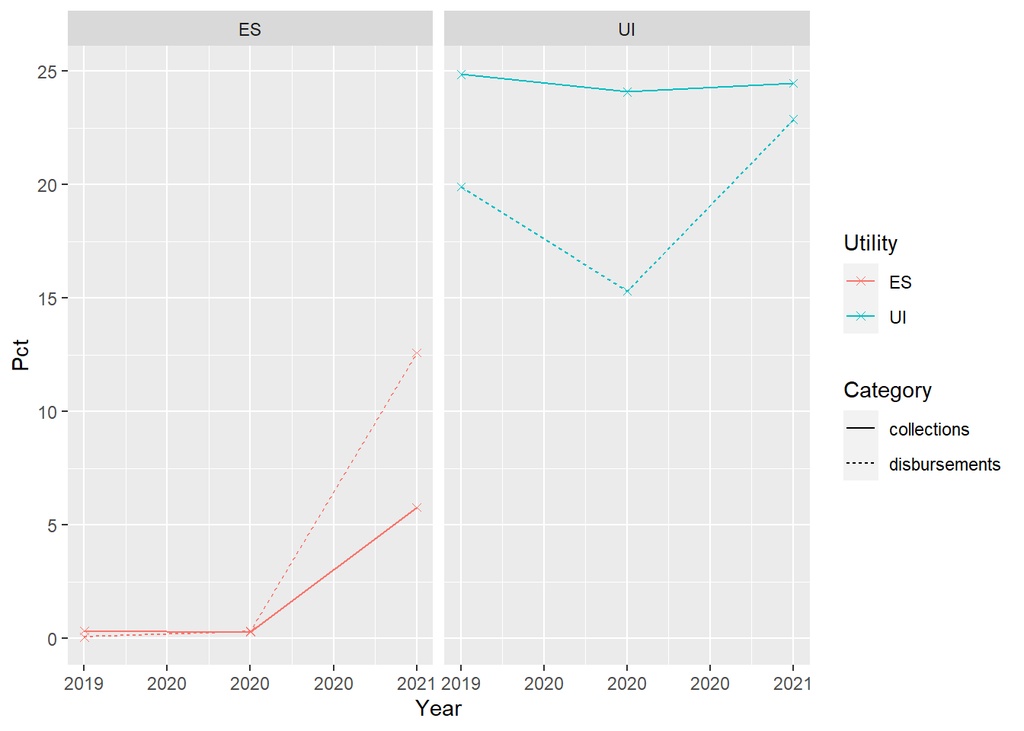

```
## # A tibble: 24 × 7
##    Size  Cat         collections disbursements Utility  Year equitable
##    <chr> <chr>             <dbl>         <dbl> <chr>   <dbl> <chr>
##  1 SMALL RESIDENTIAL   17.7             10.3   UI       2019 NO
##  2 SMALL C&I           26.9             30.0   UI       2019 YES
##  3 LARGE RESIDENTIAL   65.3              0     UI       2019 NO
##  4 LARGE C&I           31.0             29.5   UI       2019 NO
##  5 SMALL RESIDENTIAL    0.731            0.141 ES       2019 NO
##  6 SMALL C&I            0.000199         0     ES       2019 NO
##  7 LARGE RESIDENTIAL    0              NaN     ES       2019 <NA>
##  8 LARGE C&I            0.000225         0     ES       2019 NO
##  9 SMALL RESIDENTIAL   17.6              8.22  UI       2020 NO
## 10 SMALL C&I           26.4             22.9   UI       2020 NO
## # … with 14 more rows
```

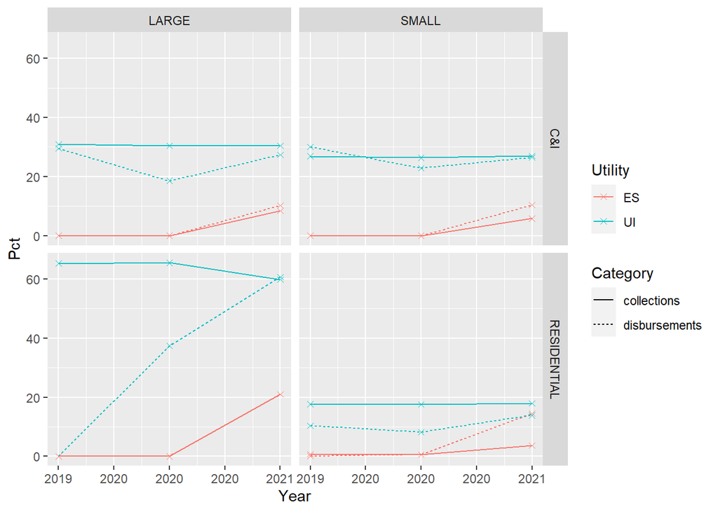

### HES and HES-IE

It makes sense that distribution of HES-IE funds would be greater to distressed census tracts, but overall funds are not equitably distributed under HES program. Moderate distress appears to participate in HES-IE.

- HES-IE: Home Energy Solutions, income-eligible
- Moderately distressed tracts: median income 60-80% state median income

```
## # A tibble: 6 × 5
##   collections disbursements Utility  Year equitable
##         <dbl>         <dbl> <chr>   <dbl> <chr>
## 1      17.7         13.5    UI       2019 NO
## 2       0.730        0.0201 ES       2019 NO
## 3      18.0         11.8    UI       2020 NO
## 4       0.588        0      ES       2020 NO
## 5      18.5         17.8    UI       2021 NO
## 6       3.72        20.1    ES       2021 YES
```

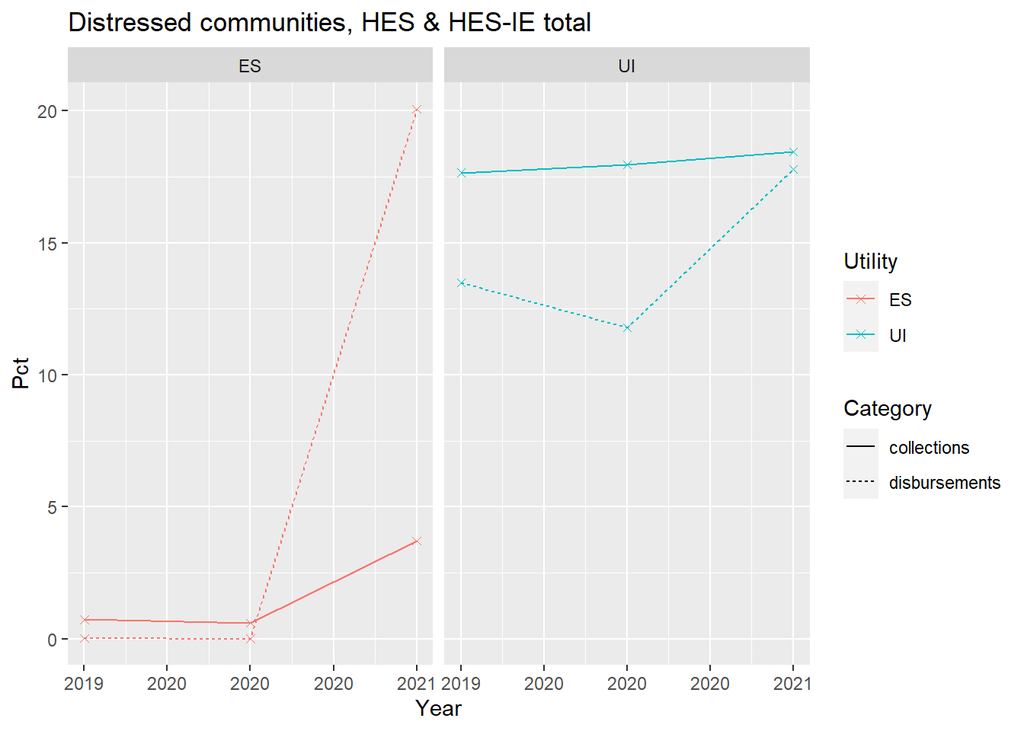

```
## # A tibble: 12 × 6
##    Cat    collections disbursements Utility  Year equitable
##    <chr>        <dbl>         <dbl> <chr>   <dbl> <chr>
##  1 HES         17.7          3.26   UI       2019 NO
##  2 HES_IE      17.7         23.9    UI       2019 YES
##  3 HES          0.730        0.0462 ES       2019 NO
##  4 HES_IE       0.730        0      ES       2019 NO
##  5 HES         18.0          3.19   UI       2020 NO
##  6 HES_IE      18.0         34.0    UI       2020 YES
##  7 HES          0.588        0      ES       2020 NO
##  8 HES_IE       0.588        0      ES       2020 NO
##  9 HES         18.5          5.06   UI       2021 NO
## 10 HES_IE      18.5         35.2    UI       2021 YES
## 11 HES          3.72         1.24   ES       2021 NO
## 12 HES_IE       3.72        51.2    ES       2021 YES
```

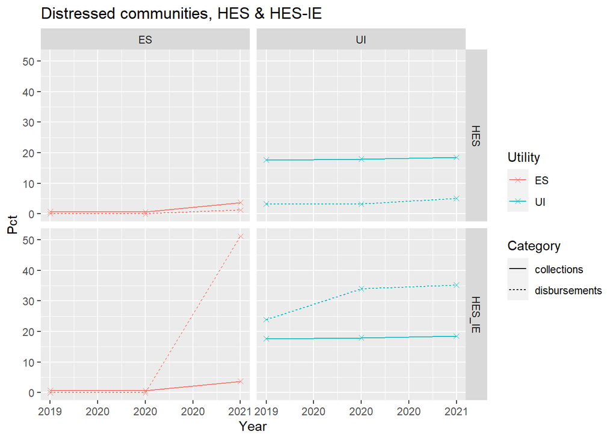

```
## # A tibble: 12 × 6
##    Cat    collections disbursements Utility  Year equitable
##    <chr>        <dbl>         <dbl> <chr>   <dbl> <chr>
##  1 HES          17.3           3.22 UI       2019 NO
##  2 HES_IE       17.3          21.4  UI       2019 YES
##  3 HES           6.96          4.26 ES       2019 NO
##  4 HES_IE        6.96         11.9  ES       2019 YES
##  5 HES          16.5           4.51 UI       2020 NO
##  6 HES_IE       16.5          22.2  UI       2020 YES
##  7 HES           6.84          2.07 ES       2020 NO
##  8 HES_IE        6.84          9.11 ES       2020 YES
##  9 HES          18.1           6.33 UI       2021 NO
## 10 HES_IE       18.1          33.9  UI       2021 YES
## 11 HES           6.26          1.66 ES       2021 NO
## 12 HES_IE        6.26         51.9  ES       2021 YES
```

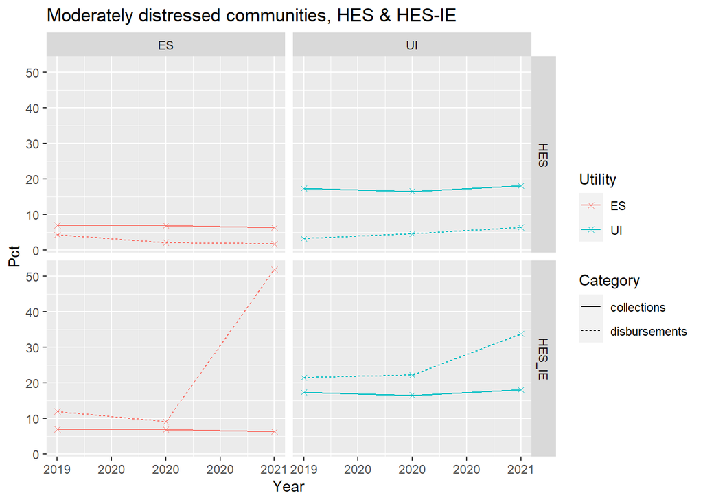

### Justice40 disadvantaged

Justice40 requires that 40% of funds flow to disadvantaged communities, which make up approximately 29% of the country. This means that these communities should receive 1.3x the average proportional investment.

- Disadvantaged: Communities that are marginalized, underserved, and overburdened by pollution. Burden thresholds include climate change, energy, health, housing, legacy pollution, transportation, water and wastewater, and workforce development.
- Black lines in the chart show targets based on 40% of budget and 1.3x proportional investment.

```
## # A tibble: 6 × 5
##   collections disbursements Utility  Year equitable
##         <dbl>         <dbl> <chr>   <dbl> <chr>
## 1       27.5           17.6 UI       2019 NO
## 2       10.4           11.7 ES       2019 YES
## 3       26.8           15.6 UI       2020 NO
## 4       10.6           12.9 ES       2020 YES
## 5       27.5           26.5 UI       2021 NO
## 6        9.75          16.1 ES       2021 YES
```

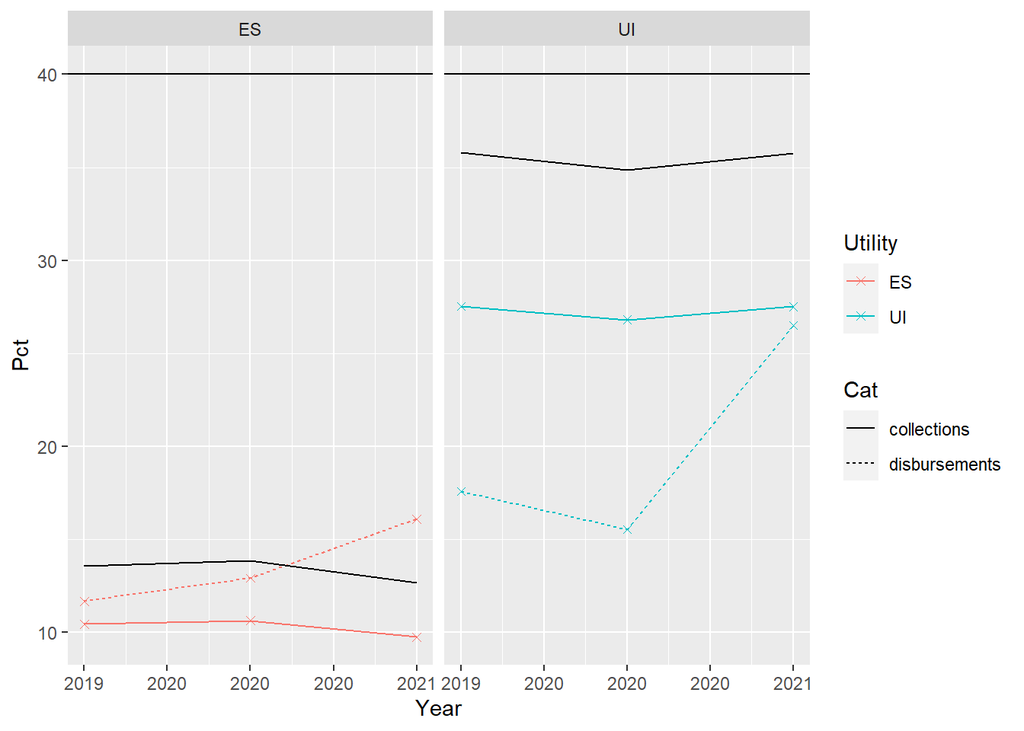

## Maps & Baselines

### Median household income

- Low: <60% of state median income
- Moderate: 60-80% of state median income
- High: >80% state median income

Must exceed baseline to be considered equitable. Baseline is proportional investment based on portion of census tracts that fall under each category.

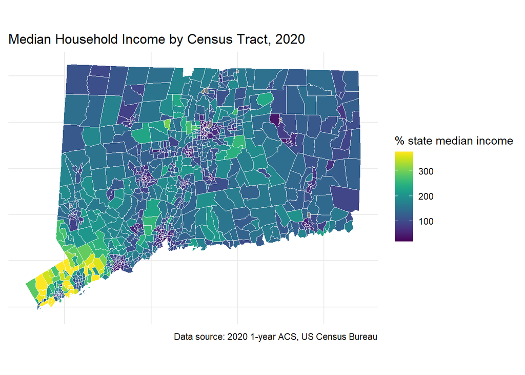

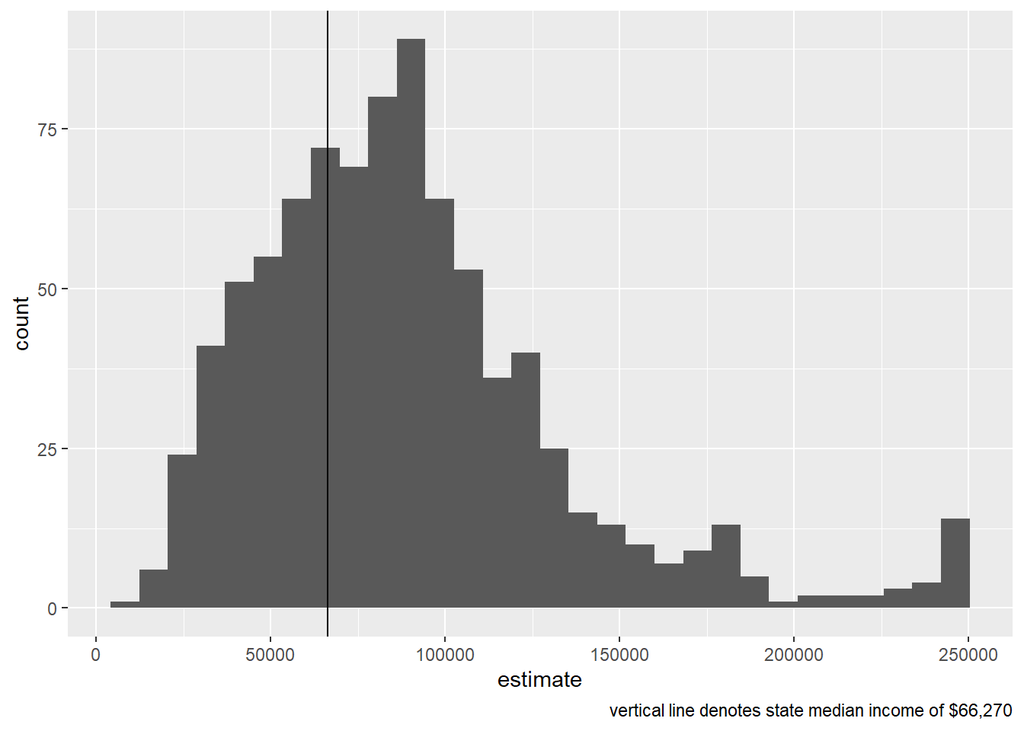

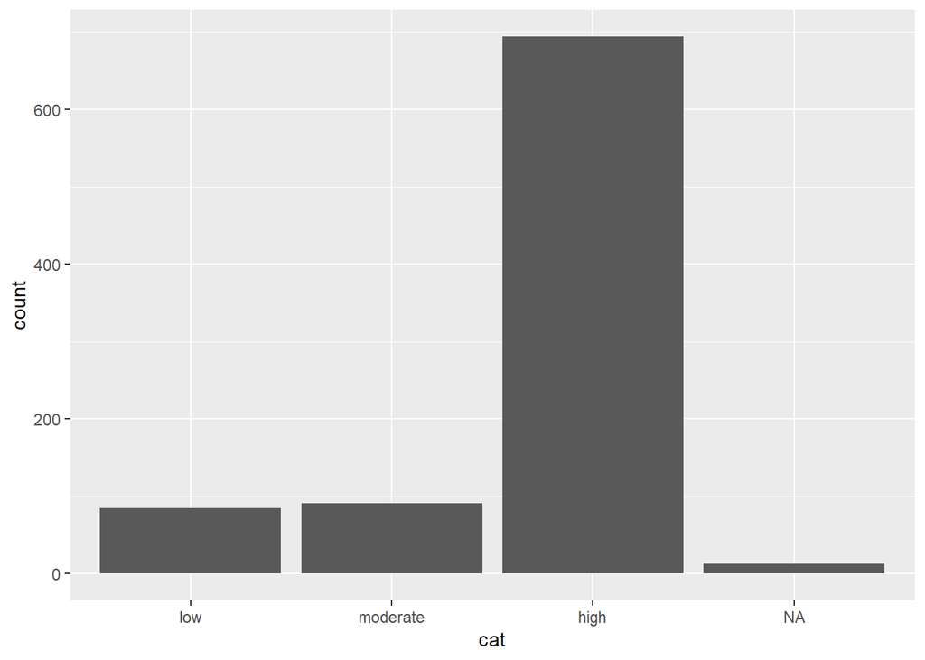

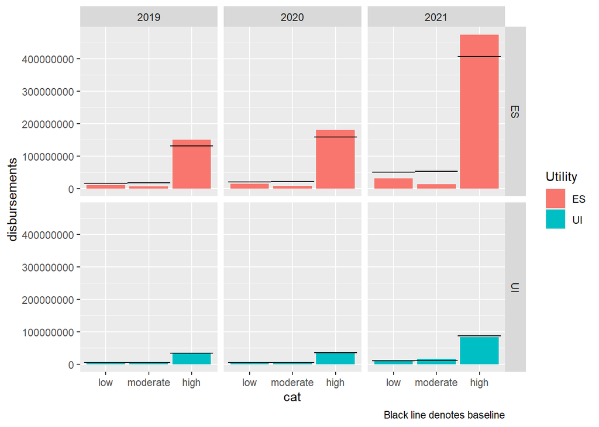

### Racial diversity

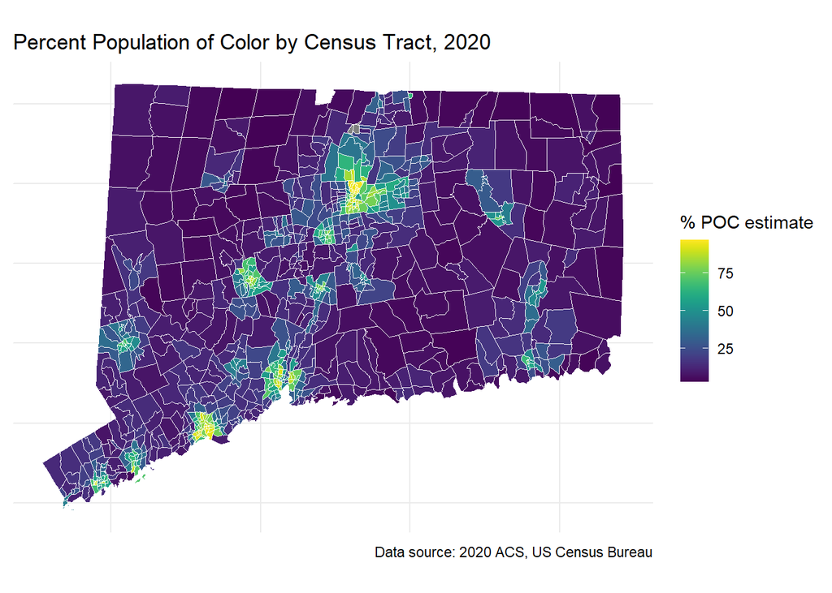

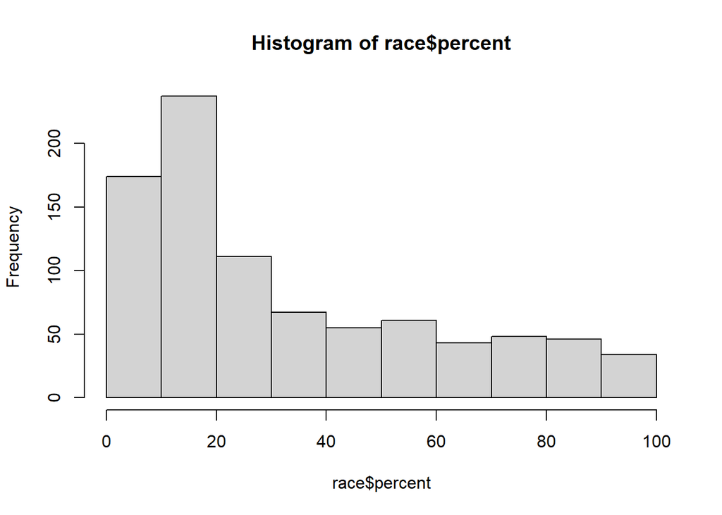

### Energy burden

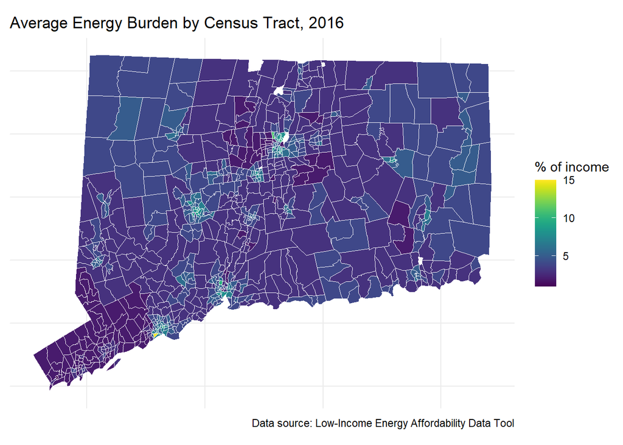

### Disbursements & Collections

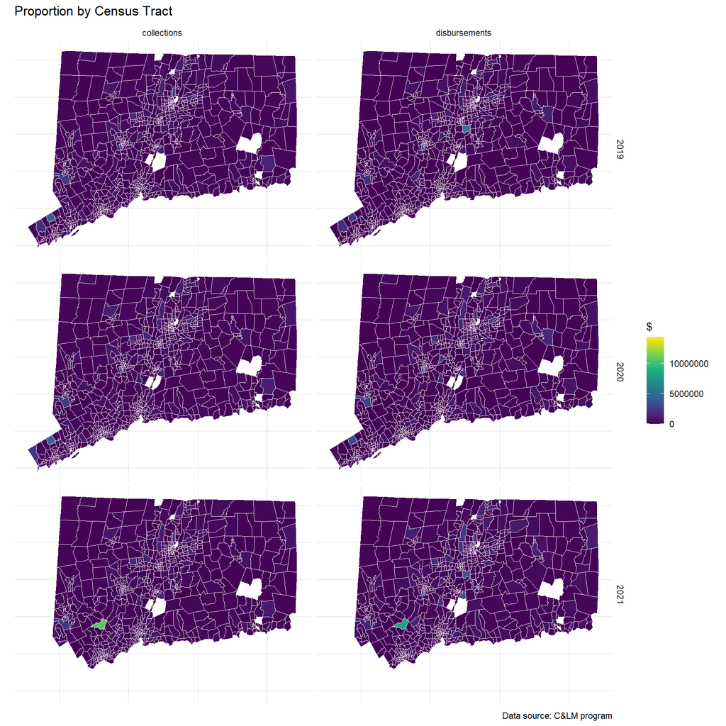